# MA 331 homework 2

Josh Gribbon

### Part 1

**Data**

Assume that N has Binomial distribution with number of trials n and probability of success p=0.4.

#### (i) For n=20, 30, 50 and 100, accurately compute P(N<=8.25) by using R function

```r
i_vals <- c()
sizes <- c(20, 30, 50, 100)
for(i in sizes){
  v <- pbinom(8.25, size=i, prob=0.4)
  i_vals <- c(i_vals, v)
  cat("n=", i, " : ", v, '\n')
}
```

```
## n= 20  :  0.5955987
## n= 30  :  0.09401122
## n= 50  :  0.0002305229
## n= 100  :  5.431127e-13
```

#### (ii) For n=20, 30, 50 and 100, compute P(N<=8.25) by using normal approximation through Laplace theorem

```r
p <- 0.4
q <- 1-p
mu_fn <- function(n, p){return (n*p)}
sd_fn <- function(n, p, q){return(sqrt(n*p*q))}
ii_vals <- c()

for(i in sizes){
  v <- pnorm(8.25, mean=mu_fn(i, p), sd=sd_fn(i, p, q))
  ii_vals <- c(ii_vals, v)
  cat("n=", i, " : ", v, '\n')
}
```

```
## n= 20  :  0.5454243
## n= 30  :  0.08112525
## n= 50  :  0.0003470073
## n= 100  :  4.557597e-11
```

#### (iii) Evaluate and plot errors of all approximation in (ii)

```r
p_err <- function(meas, act){return(abs((meas-act)/act))}
errs <- c()
diffs <- c()

for(i in 1:length(sizes)){
  measured = ii_vals[i]
  actual = i_vals[i]
  n = sizes[i]
  err <- p_err(measured, actual)
  errs <- c(errs, err)
  diff <- abs(actual-measured)
  diffs <- c(diffs, diff)
  cat("n=", n, ':', p_err(measured, actual)*100, "% error\n")
}
```

```
## n= 20 : 8.424207 % error
## n= 30 : 13.70684 % error
## n= 50 : 50.53052 % error
## n= 100 : 8291.624 % error
```

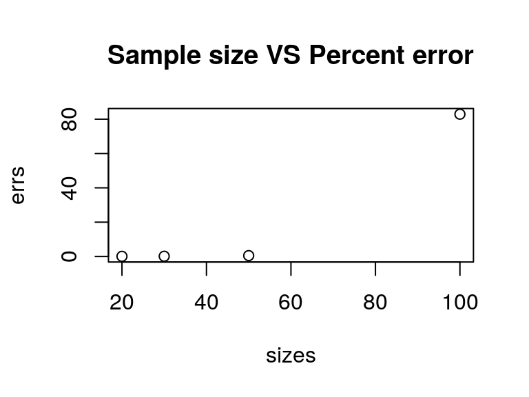

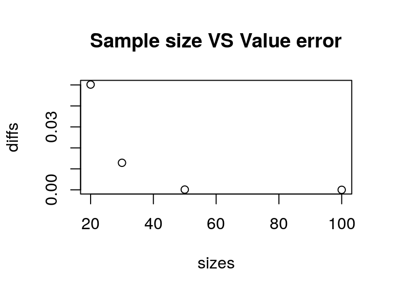

```r
plot(
  sizes, errs,
  main="Sample size VS Percent error"
)
plot(
  sizes, diffs,
  main="Sample size VS Value error"
)
```

#### (iv) What do you perceive based on the plot

As the sample size increases, amount of error decreases but the percent error increases

### Part 2

**Data**

By using R function generate a simple and random sample of size n for the population X having normal distribution with mean 2 and variance $3^2$

```r
m <- 2
v <- 3^2
srs <- function(n){
  return(rnorm(n, mean=m, sd=sqrt(v)))
}
```

#### (i) Let n=20, compute $(\bar{x}-2)/ \sqrt{3^2 /n}$ and $(n-1)S^2/3^2$ . Then, repeat (i) for 100 times and plot $(\bar{x}-2)/ \sqrt{3^2 /n}$ and $(n-1)S^2/3^2$ , respectively.

```r
n <- 20
norm_mean <- function(X){return((mean(X)-2)/sqrt(v/n))}
chisq_mean <- function(X){
  xbar <- mean(X)
  s <- 0
  for(i in 1:n){s <- s+(X[i]-xbar)^2}
  S_sqr <- (1/(n-1)) * s
  return(((n-1)*S_sqr)/v)
}
samp <- srs(n)
norm_mean(samp)
```

```
## [1] 1.546144
```

```r
chisq_mean(samp)
```

```
## [1] 19.75923
```

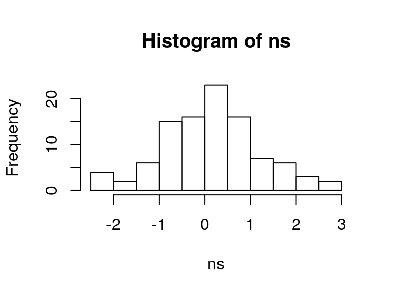

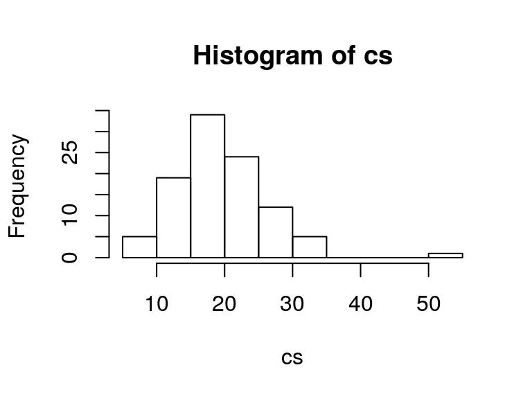

```r
ns <- c()
cs <- c()
for(i in 1:100){
  samp <- srs(n)
  ns <- c(ns, norm_mean(samp))
  cs <- c(cs, chisq_mean(samp))
}
hist(ns)
hist(cs)
```

#### (ii) For n=30, repeat (i) for 100 times and plot $(\bar{x}-2)/ \sqrt{3^2 /n}$ and $(n-1)S^2/3^2$

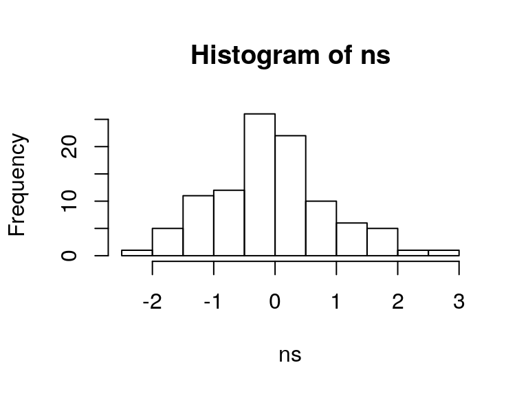

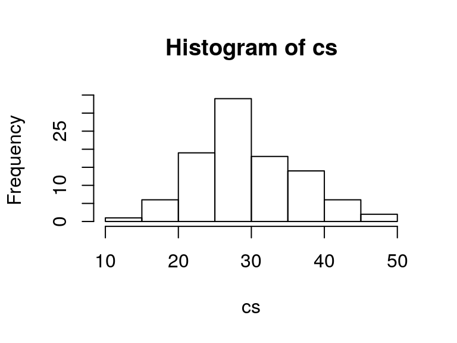

```r
n <- 30
ns <- c()
cs <- c()
for(i in 1:100){
  samp <- srs(n)
  ns <- c(ns, norm_mean(samp))
  cs <- c(cs, chisq_mean(samp))
}
hist(ns)
hist(cs)
```

#### (iii) For n=50, repeat (i) for 100 times and plot $(\bar{x}-2)/ \sqrt{3^2 /n}$ and $(n-1)S^2/3^2$

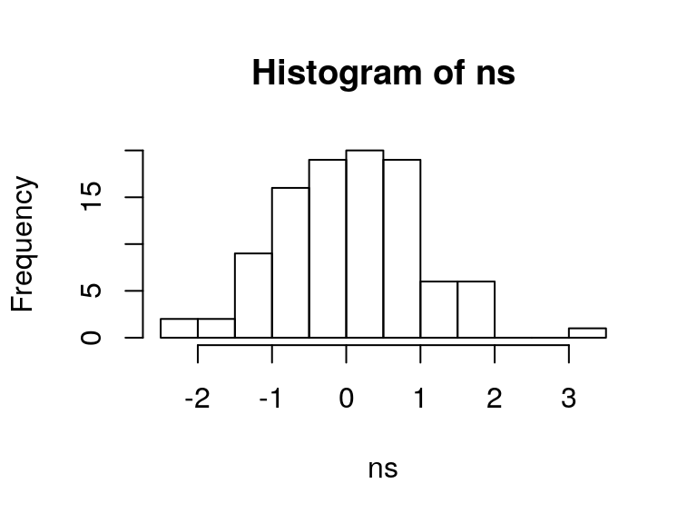

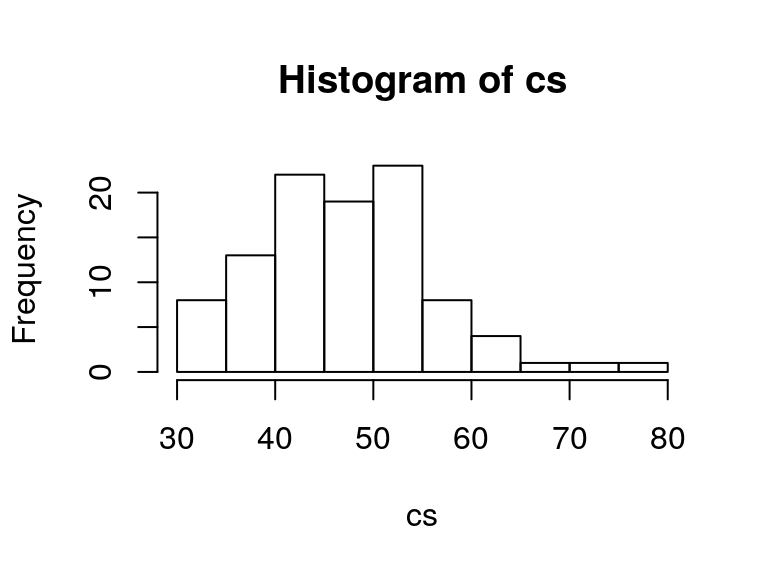

```r
n <- 50
ns <- c()
cs <- c()
for(i in 1:100){
  samp <- srs(n)
  ns <- c(ns, norm_mean(samp))
  cs <- c(cs, chisq_mean(samp))
}
hist(ns)
hist(cs)
```